# Twitter Analytics - Blueprint MCAT

Last updated June 2020

## Blueprint MCAT Twitter Metrics

This report contains information about Blueprint MCAT’s Twitter account, @Blueprint_MCAT, and how effective it is at engaging a wider audience of pre-med students.

### Data Collection - Summary

Data was collected manually on the first of the month from https://analytics.twitter.com/user/blueprint_mcat/home. This summary file contains:

- month: month of Tweet information
- year: year of Tweet information
- tweets: number of Tweets that month
- profile-visits: number of times users visited the @Blueprint_MCAT profile page
- new-followers: number of new followers gained (gross new followers; does not account for followers lost)
- tweet-impressions: number of times users are served @Blueprint_MCAT tweets in timeline, search results, or from the profile
- mentions: number of times @Blueprint_MCAT was mentioned in tweets

### Data Collection - Monthly Tweets

Data was scraped using the R package rtweet. This data contains the following parameters:

- Tweet ID: the identifier for the Tweet, which can be used to find the permanent URL
- Tweet permalink: permanent URL for the Tweet
- Tweet text: the text (content) of the Tweet
- time: the time the Tweet was sent (GMT)
- impressions: number of times users are served the tweet in timeline, search results, or from the @Blueprint_MCAT profile
- engagements: total number of times a user interacted with a Tweet. Clicks anywhere on the Tweet, including Retweets, replies, follows, likes, links, cards, hashtags, embedded media, username, profile photo, or Tweet expansion
- engagement rate: number of engagements divided by impressions
- retweets: number of times that Tweet was retweeted
- replies: number of replies that Tweet generated
- user profile clicks: number of times a user clicked on the @Blueprint_MCAT profile from that particular tweet
- URL clicks: number of times that URL within the tweet was clicked
- hashtag clicks: number of times any of your hashtags were clicked from that tweet
- detail expands: number of times users clicked ‘see more’ on your tweet
- permalink clicks: clicks on the Tweet permalink
- follows: times a user followed you directly from the Tweet
- email tweet: number of times the Tweet is shared by email
- media views: number of times media attached to the Tweet is viewed
- media engagements: an interaction on a tweet that has a piece of media (photo, vine, other video, etc) in it

## Summary Information

#### Top 10: Most Liked Tweets

| Tweet | Date and Time | Likes | Retweets | Hashtags Used |
| --- | --- | --- | --- | --- |
| What do you REALLY need to study for the new #MCAT? #medschool #MCAT2015 http://t.co/6jOgzEThrt http://t.co/tyFgb3zNMV | 2014-08-23 00:52:09 | 22 | 11 | MCAT, medschool, MCAT2015 |
| You might not save the entire galaxy by studying for the MCAT, but you might end up being someone’s superhero. Start your training for free today! https://t.co/7G6KSmnb4R https://t.co/DarrW3IAHS | 2019-04-26 05:21:03 | 8 | 2 | NA |
| Getting started with the #MCAT exam? Our free practice bundle is the perfect place to begin. Register now https://t.co/4lxHqOEbjm https://t.co/ANAdGXnaGp | 2018-01-04 19:16:25 | 8 | 4 | MCAT |
| Early reports coming in from today’s MCAT takers are looking promising! Most are encouraging future test takers to practice taking shorter breaks and wearing a face mask while taking practice full-len… | 2020-05-29 18:46:45 | 7 | 1 | NA |
| BREAKING: The AAMC has announced they are delaying sending applicant data to schools by 2 weeks (July 10th, instead of June 26th) in an attempt to give students additional time to complete the 2021 #A… | 2020-04-20 21:31:06 | 7 | 0 | AMCAS |
| “In a dark place we find ourselves, and a little more knowledge lights our way.” https://t.co/USXcuGMHu5 | 2019-12-12 21:15:06 | 7 | 2 | NA |
| The MCAT can easily take over your life. However, while it might be easy to go through the drive-thru, you shouldn’t sacrifice healthy eating. Choosing healthy snacks and meals can keep your energy an… | 2019-05-08 04:27:03 | 6 | 2 | StudyTipTuesday |
| I just want a leg please. Happy Thanksgiving from all of us at Next Step! https://t.co/h4l9lqvGXF | 2019-11-28 23:03:05 | 5 | 1 | NA |
| Say it louder for people in the back! 🗣🗣🗣 https://t.co/FYk2E4v0I0 | 2019-08-05 16:59:14 | 5 | 1 | NA |
| Pre-Meds and Med Students, we need you! Tell us how you prevent burnout when studying for the MCAT or while in med school! What are your best tips, strategies, secrets, etc. Sound off below! https://t… | 2019-02-13 01:00:04 | 5 | 1 | NA |

#### Top 10: Most Retweeted Tweets

| Tweet | Date and Time | Likes | Retweets | Hashtags Used |
| --- | --- | --- | --- | --- |
| What do you REALLY need to study for the new #MCAT? #medschool #MCAT2015 http://t.co/6jOgzEThrt http://t.co/tyFgb3zNMV | 2014-08-23 00:52:09 | 22 | 11 | MCAT, medschool, MCAT2015 |
| Getting started with the #MCAT exam? Our free practice bundle is the perfect place to begin. Register now https://t.co/4lxHqOEbjm https://t.co/ANAdGXnaGp | 2018-01-04 19:16:25 | 8 | 4 | MCAT |
| #MCAT #Biology practice problem on actional potential - if you are having troublel let us know! https://t.co/dyxAbksz1e | 2016-07-27 14:03:03 | 3 | 3 | MCAT, Biology |
| Anyone taking a March or April MCAT can call Pearson directly to reschedule their exam for FREE! Fees will not be refunded if you reschedule online. Be prepared for long wait times! | 2020-03-12 19:24:31 | 2 | 3 | NA |
| #MCAT #chemistry practice problem for you #premed students https://t.co/xZEQv58XRP | 2016-09-26 14:03:59 | 2 | 3 | MCAT, chemistry, premed |
| RT @Leah4Sci: Just got my @nextstepprep #MCAT books. Time to verify the great things I’ve heard from my students http://t.co/pmjJTscPty | 2015-06-24 19:10:54 | 2 | 3 | MCAT |
| Happy Monday! Start your week with today’s MCAT #QuestionOfTheDay! For answer and full explanation: https://t.co/g3L1g3yh4S https://t.co/Byxft1QcQc | 2019-10-28 21:42:06 | 1 | 3 | QuestionOfTheDay |
| You might not save the entire galaxy by studying for the MCAT, but you might end up being someone’s superhero. Start your training for free today! https://t.co/7G6KSmnb4R https://t.co/DarrW3IAHS | 2019-04-26 05:21:03 | 8 | 2 | NA |
| “In a dark place we find ourselves, and a little more knowledge lights our way.” https://t.co/USXcuGMHu5 | 2019-12-12 21:15:06 | 7 | 2 | NA |
| The MCAT can easily take over your life. However, while it might be easy to go through the drive-thru, you shouldn’t sacrifice healthy eating. Choosing healthy snacks and meals can keep your energy an… | 2019-05-08 04:27:03 | 6 | 2 | StudyTipTuesday |

#### Distribution of replies, retweets, and organic tweets

Analyzing the ratio of replies, retweets and organic tweets can tell you a great deal about the type of account you’re analysing. No one likes a Twitter account that exclusively retweets for instance, without any individual content. Finding a good ratio of replies, retweets and organic tweets is therefore a key metric to monitor if one wishes to improve the performance of an account.

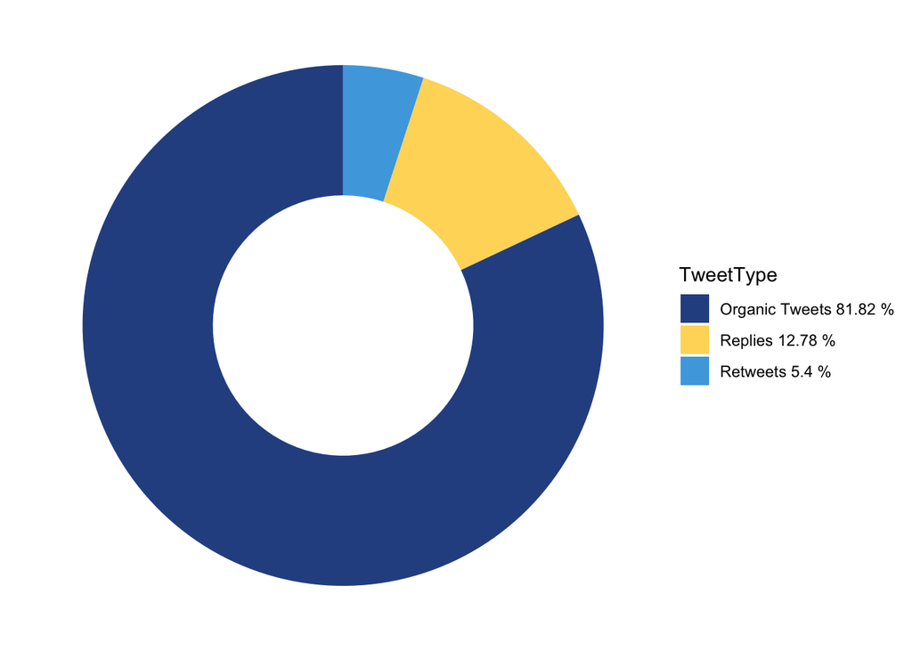

### Tweet Text Analysis

Bar graph illustrating the 15 most commonly tweeted words in @Blueprint_MCAT’s tweets, with common stop words removed from the list.

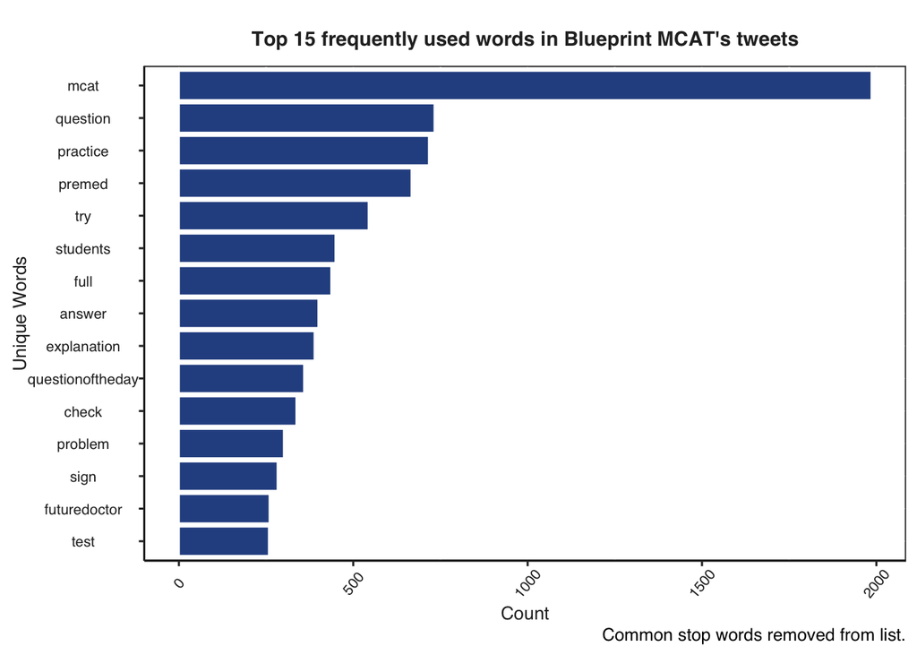

### Showing the most frequently used hashtags

Hashtags used more than 10 times are displayed in the wordcloud below.

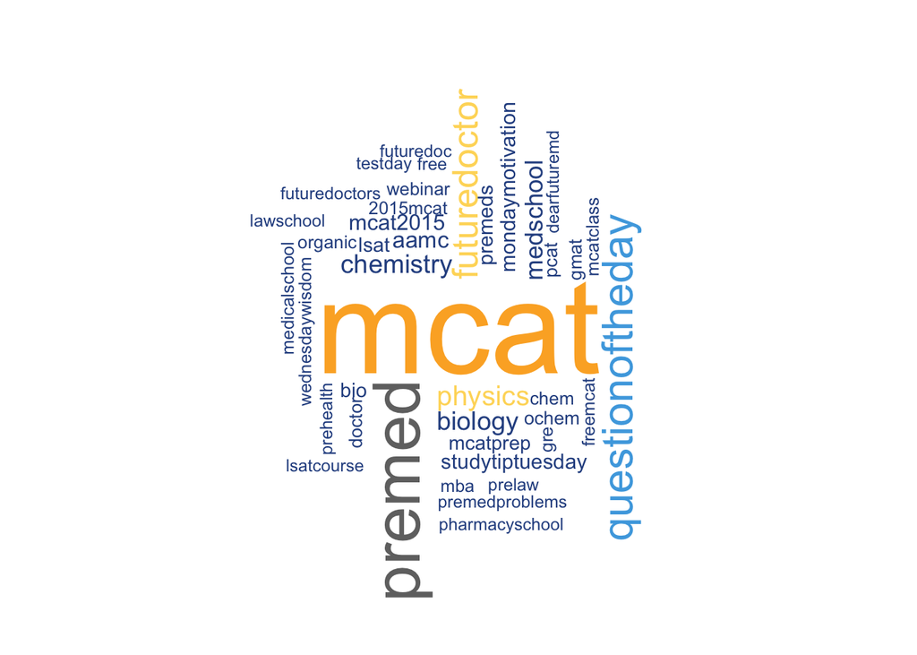

### Understanding what accounts we frequently retweet

Retweeting extensively from one account is usually not what someone looks for in a Twitter account. A helpful insight is therefore to monitor and understand from which accounts most retweets originate. Accounts are shown that we have retweeted more than 3 times.

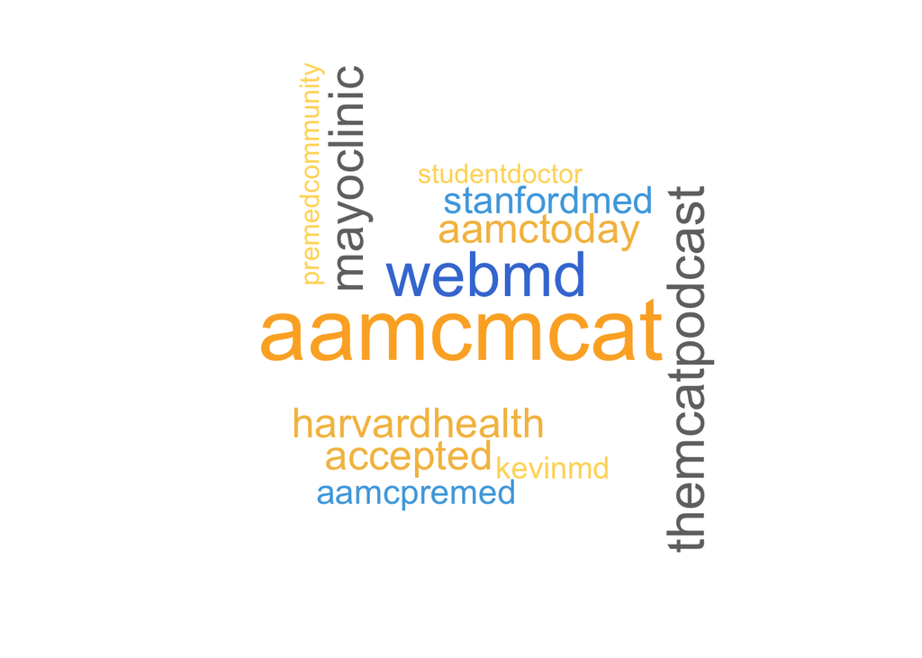

### Understanding the sentiment of tweet content

No one likes a Twitter account that only spreads angry or sad tweets. Capturing the tone of your tweets and how they balance out is a good indication of your account’s performance.

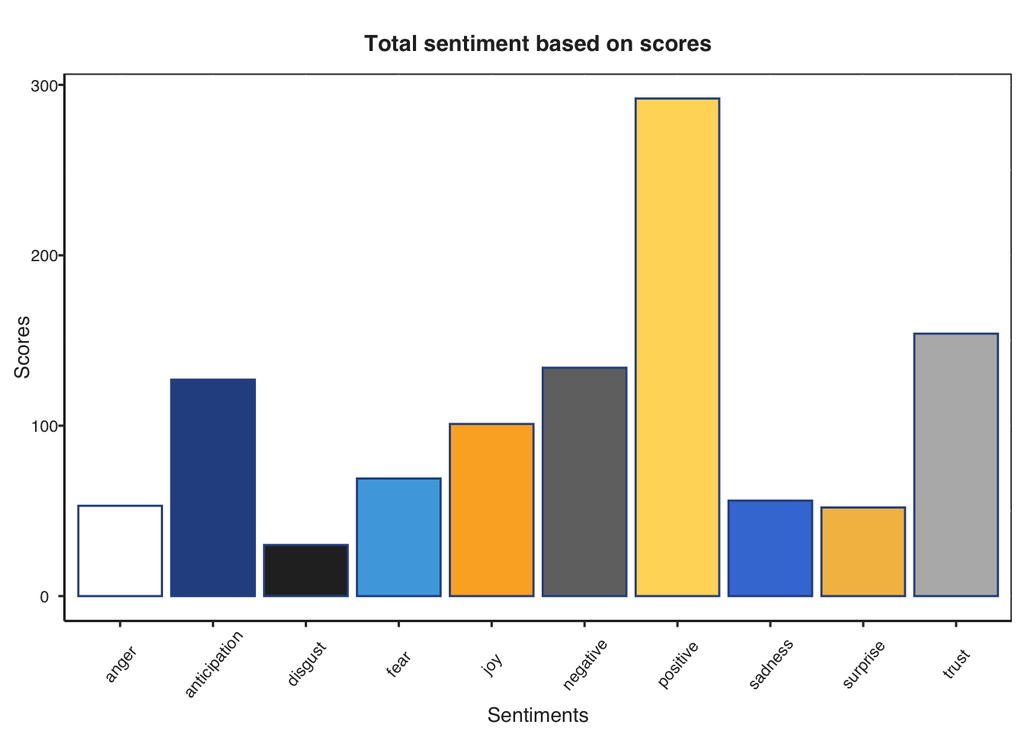